# Sustainability labels on food products: Consumer motivation, understanding and use - ScienceDirect

- [View **PDF**](https://www.sciencedirect.com/science/article/pii/S0306919213001796/pdfft?md5=51880a6e1984d3ee16e84122b61e603b&pid=1-s2.0-S0306919213001796-main.pdf)

## [Food Policy](https://www.sciencedirect.com/journal/food-policy)

[Volume 44](https://www.sciencedirect.com/journal/food-policy/vol/44/suppl/C), February 2014, Pages 177-189

# Sustainability labels on food products: Consumer motivation, understanding and use

[Klaus G. Grunert <sup>a</sup>](https://www.sciencedirect.com/author/7004726565/klaus-g-grunert), ,

https://doi.org/10.1016/j.foodpol.2013.12.001[Get rights and content](https://s100.copyright.com/AppDispatchServlet?publisherName=ELS&contentID=S0306919213001796&orderBeanReset=true)

Under a Creative Commons [license](http://creativecommons.org/licenses/by-nc-nd/3.0/)

Open access

## Highlights

- •

  Consumers link the term ‘sustainability’ mostly to [environmental issues](https://www.sciencedirect.com/topics/social-sciences/environmental-issue).
- •

  At the general level, consumers express concern with environmental issues.
- •

  At the product-related level, this concern diminishes.
- •

  Consumers have limited awareness of sustainability labels, but can guess their meaning.
- •

  Level of use of sustainability labels is low.

## Abstract

This study investigates the relationship between consumer motivation, understanding and use of sustainability labels on food products (both environmental and ethical labels), which are increasingly appearing on food products. Data was collected by means of an online survey implemented in the UK, France, Germany, Spain, Sweden, and Poland, with a total sample size of 4408 respondents. Respondents expressed medium high to high levels of concern with sustainability issues at the general level, but lower levels of concern in the context of concrete food product choices. Understanding of the concept of sustainability was limited, but understanding of four selected labels (Fair Trade, Rainforest Alliance, Carbon Footprint, and Animal Welfare) was better, as some of them seem to be self-explanatory. The results indicated a low level of use, no matter whether use was measured as self-reported use of different types of information available on food labels or as use inferred from the results of a choice-based conjoint analysis. Hierarchical regression indicated that use is related to both motivation and understanding, and that both motivation, understanding and use are affected by demographic characteristics, human values as measured by the Schwartz value domains, and country differences. The results imply that sustainability labels currently do not play a major role in consumers’ food choices, and future use of these labels will depend on the extent to which consumers’ general concern about sustainability can be turned into actual behaviour.

- [Previous article in issue](https://www.sciencedirect.com/science/article/pii/S0306919213001772)
- [Next article in issue](https://www.sciencedirect.com/science/article/pii/S0306919213001826)

## Keywords

Consumer behaviour

Food labelling

Sustainability

## Introduction

Over the last three decades, a number of public and private initiatives have started communicating sustainability-related information about food to consumers, introducing labels and logos in-store and on-pack. Among the more prominent ones are the Fair Trade logo, the Rainforest Alliance logo, various carbon index schemes and animal welfare-related logos. According to cataloguer ecolabelindex.com, approximately 432 labelling schemes are available in 246 countries, of which 147 include standards for food/beverage. A survey by the European Commission identified 129 public and private sustainability-related food information schemes available at the EU or national levels (European Commission, 2012). The objective of these schemes is to increase transparency along the food chain and inform the consumer in a way that can promote sustainable consumption. It is commonly believed that food consumption and dietary choices can make an important contribution to meeting current environmental challenges. Informed choice, much as in the case of [nutrition labelling](https://www.sciencedirect.com/topics/agricultural-and-biological-sciences/nutrition-labeling), is hoped to empower people to consume more sustainably (European Commission, 2008).

While the growth in labels and accompanying communication initiatives may be interpreted as a sign of success and sales of products carrying sustainability labels are reported to increase (e.g., Fair Trade UK reports an overall sales increase of 12% from 2010 to 2011), label overload and gaps in the understanding of both the general concept of sustainability and of specific sustainability labels may result in consumer confusion and limit the use of such labels (Comas Marti and Seifert, 2012, Grunert, 2011, Horne, 2009). Also, while sustainability is an issue of general interest, in the context of food choice it competes with other issues like [sensory quality](https://www.sciencedirect.com/topics/food-science/sensory-quality) and healthfulness, and a general interest in sustainability may therefore not necessarily translate into use of sustainability information when choosing food products.

It is the purpose of this paper to shed light on European consumers’ understanding, motivation and use of sustainability labelling, in order to better understand the role sustainability information plays in a food and drink context. Sustainability is a multidimensional concept, and we follow the World Commission on Environmental Development’s view (WCED, 1987) as sustainability having two dimensions, a temporal dimension and a social dimension. The temporal dimension is related to trade-offs between present and future and mainly related to [environmental issues](https://www.sciencedirect.com/topics/social-sciences/environmental-issue), whereas the social dimension is related to trade-offs between consumers and others, commonly subsumed under the heading of ethical issues. In investigating the effect of sustainability labels on food products on consumers, we will hence distinguish between environmental labels and ethical labels.

## Literature review

While there is no doubt about the importance of sustainable consumption (Nash, 2009), current research on the subject is quite fragmented. The existing literature has a focus on organic consumption (e.g., Aertsens et al., 2009, Hughner et al., 2007, Janssen and Hamm, 2012, McEachern and Warnaby, 2008, Zakowska-Biemans, 2011), but offers only few studies on other environmental and ethical aspects. Similarly, when investigating [consumer attitudes](https://www.sciencedirect.com/topics/social-sciences/consumer-attitude) towards sustainability, most studies focus on selected product categories and/or labels and results are difficult to generalise (e.g., Brecard et al., 2009, Dutra de Barcellos et al., 2011, Kimura et al., 2012).

Most research can be found on the more popular labelling schemes such as Fair Trade and [animal welfare](https://www.sciencedirect.com/topics/agricultural-and-biological-sciences/animal-welfare) logos. Many studies focus on [willingness to pay](https://www.sciencedirect.com/topics/social-sciences/willingness-to-pay) and/or self-reported purchase intentions (e.g., Grankvist and Biel, 2007, Johnston, 2008). These studies suggest that consumers are willing to pay price surcharges of 10% for Fair Trade labelled products (De Pelsmacker et al., 2005, Kimura et al., 2010, Napolitano et al., 2008, Zander and Hamm, 2010). However, when asked about the main barriers to purchase and use of sustainable products, perceived high price is among the top answers (for carbon labelling, Röös and Tjärnemo, 2011; for eco-labels in general, Grunert, 2011). For animal welfare labelled products, it has been found that knowledge about labels and the standards they are based on can play a significant role in influencing purchase decisions (McEachern and Warnaby, 2008). In line with this finding, Hoogland et al. (2007) have shown that the inclusion of details about animal welfare standards for meat and [dairy products](https://www.sciencedirect.com/topics/food-science/dairy-product) can lead to [positive consumer](https://www.sciencedirect.com/topics/social-sciences/positive-consumer) reactions, albeit net impact on purchase intentions remains small. Analysing motives behind fair trade purchases, Kimura et al. (2012) found that fair trade labelled purchases are not just driven by intrinsic motives for ethical issues, but can also be affected by extrinsic social factors such as the concern for one’s own reputation among peers (see also Brecard et al., 2009, Sirieix, 2008). This is in line with research by Vermeir and Verbeke (2006), who suggested that sustainable food consumption can be stimulated by increasing consumer involvement, perceived effectiveness (of sustainable products) and raising social peer pressure. A study in France has shown that local organic consumers are not at all concerned about food miles, because they have other motivations for buying local food (Sirieix et al., 2008). Some researchers have also looked at the more basic underlying motivations for sustainable choices by trying to link interest in sustainable products to human values like universalism (Hoogland et al., 2007).

In summary, previous studies suggest that the motivation to behave sustainably is frequently found among consumers, while its translation into actual sustainable food choice and consumption seems more difficult (e.g., Bray et al., 2011, Chatzidakis et al., 2007, De Boer et al., 2009, Dutra de Barcellos et al., 2011, Krystallis et al., 2009). This may be partly related to the fact that the purchase of food and drink underlies constant trade-offs. Horne (2009, p. 175) states that “*(…) consumers remain full of* *[intent](https://www.sciencedirect.com/topics/social-sciences/intention)* *to purchase sustainably, yet these* *[stated preferences](https://www.sciencedirect.com/topics/social-sciences/contingent-valuation)* *have not translated into a widespread uptake in the purchase of more sustainable products.*” Product attributes such as price, brand, quantity, use-by-date and nutrition information compete with eco-labels for consumer awareness, perceived relevance and influence on choice behaviour. To date, little research has assessed how consumers weigh these attributes, and which relative importance is assigned to environmental and ethical issues.

Previous research thus points to the importance of [consumer motivation](https://www.sciencedirect.com/topics/social-sciences/consumer-motivation) and consumer knowledge for use of sustainability information on food products, and additionally underlines the importance of trade-offs between sustainability and other product information when making food choices. In drawing on these results, we will in the next section develop a uniform framework linking consumer motivation, understanding and use of sustainability information on food products, and then present empirical evidence on the interrelationship of these constructs, based on field work conducted with consumers in six European countries.

## Conceptual framework and aim of study

In developing a conceptual framework for our study, we draw on previous work explaining human behaviour as being determined by three groups of factors: motivation, ability and opportunity. This framework which has its roots in psychology (e.g., Lewin, 1951) has appeared in a number of different guises, all relevant to our current study. It has been proposed as a framework for explaining how consumers react to advertising information (MacInnis et al., 1991), noting that any [advertising effects](https://www.sciencedirect.com/topics/social-sciences/advertising-effect) depend on the consumer’s opportunity to process the ad information (related to the amount of exposure to the information), on the consumer’s ability to interpret the ad information and make inferences from it, and finally on the consumer’s motivation to engage in processing the information, as the latter will determine the depth of processing and hence the type of memory trace that the ad message leaves (Petty and Cacioppo,1996). The approach has later been adopted for the analysis of other types of communication (Hallahan, 2000), including attempts to induce environmentally friendly behaviour (Ölander and Thøgersen, 1995) and other types of [social marketing](https://www.sciencedirect.com/topics/social-sciences/social-marketing) (Rothschild, 1999). Though not relevant for the present study, we can also note that the framework is not limited to the analysis of attempts to influence human behaviour by information, but can also be applied to the analysis of effects of non-informational measures on human behaviour (see Thøgersen, 2009, for a recent example of a non-information measure aimed at promoting environmentally friendly behaviour).

Sustainability labels give consumers the opportunity to take into account environmental and ethical considerations when making food choices. Without such labels, taking into account such factors is still possible – for example, by preferring locally produced products because of a belief that transportation of food over long distances is not good for the environment – but rests on uncertain grounds and needs more indirect inferences from other product characteristics (like the origin of the food). However, giving consumers the opportunity does not imply that they will actually use it. It will depend on their motivation to make use of sustainability information – the more motivated consumers are, the more they are willing to put effort into understanding the labels and using them in the trade-offs of various product attributes that finally determines their choice. It will also depend on whether consumers actually understand what these labels mean, i.e., their ability to make use of the information. If the labels are unknown and/or their meaning not clear, even a motivated consumer cannot use them.

While most applications of the motivation, ability and opportunity framework treat these three constructs as additive, independent determinants of behaviour, in our case motivation and understanding will most likely be related. First of all, a higher degree of motivation for using sustainability labels will most likely lead to more understanding, as the motivation will motivate not only the sustainable choice, but also the learning of information that can be helpful in making sustainable choices. Secondly, one can argue that the degree of understanding can moderate the relationship between motivation and use, as a higher degree of understanding makes it easier for the consumer to convert the motivation into actual behaviour.

This leads us to the conceptual framework depicted in Fig. 1. Making sustainability labels available on food products opens up new ways of making choices for consumes, and we are interested in whether consumer are motivated to use these, whether they understand them, and how motivation and understanding together impact on use of these labels.

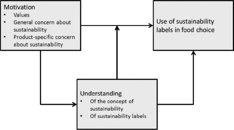

1. [Download: Download full-size image](https://ars.els-cdn.com/content/image/1-s2.0-S0306919213001796-gr1.jpg)

Fig. 1. Conceptual model.

We should note that motivation can be defined at different levels. Human values are commonly viewed as the most abstract level of motivation (Schwartz, 1992) and have been related to sustainable behaviours (e.g., Thøgersen and Ölander, 2002, Vermeir and Verbeke, 2006). At a less abstract level, environmental concern (Van Liere and Dunlap, 1981) has been identified as a source of motivation for sustainable behaviours. Still, while consumers with a higher level of environmental concern are generally more likely to engage in sustainable behaviours (e.g., Mainieri et al., 1997, Roberts and Bacon, 1997), being generally concerned about sustainability issues does not necessarily imply that consumers are also motivated to engage in a sustainable manner when choosing food.

Also understanding can be defined at different levels. We are here mainly interested in consumer understanding of sustainability in the context of [food labels](https://www.sciencedirect.com/topics/food-science/food-package-labeling), but will also look into whether consumers are familiar with the concept of sustainability in general.

Understanding can influence the use of sustainability labels in food choice directly, and it can do so by moderating the influence of motivation. Understanding can facilitate the effect of motivation on choice by enabling the more motivated consumers to actually apply the labels in a meaningful way. But understanding can also have a direct effect in that even less motivated consumers may be more likely to use sustainability labels if they understand what these stand for.

## Methodology

The study was implemented as an online survey in six European countries (UK, France, Germany, Spain, Sweden, and Poland). The countries chosen for this study represent a geographical and cultural spread throughout Europe, but also ensure a difference in penetration of sustainability labelling and general public attention to the topic of sustainability.

Four sustainability labels were chosen as examples for measuring understanding and use. Two labels deal with the environmental dimension of sustainability (Rainforest Alliance, Carbon Footprint) and the two others with the ethical dimension (Fair Trade, Animal Welfare), with considerable differences expected regarding consumer awareness and understanding of the labels. Furthermore, all four labels are used internationally and can be considered most widespread in their use on food and drink products. For validation purposes, we also measured awareness of the EU eco-label, which cannot presently be found on food and drink products. These labels can be seen in Fig. 2, Fig. 2A.

[figure not shown]

1. [Download: Download full-size image](https://ars.els-cdn.com/content/image/1-s2.0-S0306919213001796-gr2.jpg)

Fig. 2. Sustainability labels used in the study.

[figure not shown]

1. [Download: Download full-size image](https://ars.els-cdn.com/content/image/1-s2.0-S0306919213001796-gr2a.jpg)

Fig. 2A. European eco-label.

Six product categories were selected to investigate product-specific motivation to process sustainability information and for measuring use of the label information. These were chocolate, coffee, ice cream, [breakfast cereal](https://www.sciencedirect.com/topics/food-science/breakfast-cereal), ready meals and soft drinks.

### Measures

The questionnaire was designed to measure the major constructs in the conceptual model in Fig. 1: motivation, understanding and use of sustainability information on food products.

*Motivation* was measured at three levels. At the most general level, personal values were measured using the Schwartz Portrait Values questionnaire (Schwartz et al., 2001), a projective technique for measuring the personal relevance of the ten Schwartz value domains (Schwartz, 1992). Participants were asked to read portrait descriptions of hypothetical persons and compare the portrait to themselves, by providing ratings on a scale with the end points 1 = “not like me at all” and 6 = “very much like me”. Answers to the 22 items were combined into scores for the 10 Schwartz value domains according to the procedure described by Schwartz et al. (2001). Respondents’ motivation with regard to sustainability issues related to food in general was measured by asking respondents how concerned they were with 14 different aspects of sustainability. Concern was measured on a 7-point scale with the end points 1 = “only slightly concerned” and 7 = “extremely concerned” to ensure optimal scale use. The 14 items can be seen in Table 2 and cover both environmental and ethical aspects of sustainability. In addition, for each of the products used as examples, respondents were further asked to indicate the top three items they were most concerned with.

Table 1. Socio-demographic characteristics of the sample (% per country).

| Empty Cell | UK | France | Germany | Spain | Poland | Sweden |
| --- | --- | --- | --- | --- | --- | --- |
| *Gender* |  |  |  |  |  |  |
| • Female | 50.8 | 50.6 | 55.0 | 47.5 | 50.8 | 50.7 |
| • Male | 49.2 | 49.4 | 45.0 | 52.5 | 49.2 | 49.3 |
| *Age* |  |  |  |  |  |  |
| • 18–24 | 11.1 | 12.9 | 10.2 | 9.8 | 16.3 | 13.2 |
| • 25–34 | 16.4 | 19.7 | 16.9 | 23.9 | 19.1 | 17.0 |
| • 35–44 | 19.9 | 22.2 | 25.2 | 23.4 | 17.9 | 19.6 |
| • 45–54 | 16.4 | 20.0 | 23.6 | 18.6 | 22.8 | 19.1 |
| • 55+ | 36.0 | 25.2 | 24.2 | 24.2 | 23.9 | 31.0 |
| *Children* |  |  |  |  |  |  |
| • 0 | 71.8 | 62.8 | 68.1 | 70.3 | 48.2 | 72.1 |
| • 1 | 12.6 | 17.0 | 18.0 | 18.2 | 25.7 | 14.1 |
| • 2 or more | 15.6 | 20.2 | 13.9 | 11.5 | 26.1 | 13.8 |
| *Education*<sup>a</sup> |  |  |  |  |  |  |
| • Low | 15.4 | 21.8 | 31.2 | 28.0 | 10.3 | 21.6 |
| • Medium | 51.0 | 42.5 | 43.9 | 33.7 | 63.7 | 49.0 |
| • High | 33.6 | 35.7 | 24.9 | 38.3 | 26.0 | 29.4 |
| *Social class*<sup>b</sup> |  |  |  |  |  |  |
| • 1 | 42.5 | 45.3 | 39.2 | 38.9 | 45.1 | 37.1 |
| • 2 | 20.0 | 18.4 | 23.0 | 15.6 | 9.2 | 22.4 |
| • 3 | 8.5 | 3.9 | 6.9 | 7.3 | 9.3 | 4.7 |
| • 4 | 10.2 | 14.1 | 14.7 | 16.0 | 17.8 | 12.4 |
| • 5 | 18.8 | 18.3 | 16.2 | 22.2 | 18.6 | 23.4 |
| *N* | 602 | 866 | 811 | 661 | 658 | 810 |

**a**

Low: primary or [lower secondary education](https://www.sciencedirect.com/topics/social-sciences/lower-secondary-education), medium: vocational or upper [secondary education](https://www.sciencedirect.com/topics/agricultural-and-biological-sciences/secondary-education), high: higher education.

**b**

Social class was calculated using the NS-SEC self-coded method, with 1 = managerial and professional occupations, 2 = intermediate occupations, 3 = small employers and own account workers, 4 = lower supervisory and [technical occupations](https://www.sciencedirect.com/topics/social-sciences/technical-occupation) and 5 = semi-routine and routine occupations.

Table 2. Concern about sustainability issues.

| Empty Cell | Mean | Std. deviation |
| --- | --- | --- |
| The use of child labour in food production | 5.53 | 1.67 |
| Deforestation of the rain forest | 5.45 | 1.61 |
| Starvation and malnutrition in the world population | 5.39 | 1.65 |
| The use of pesticides used in food production | 5.38 | 1.63 |
| Poor treatment of animals in food production | 5.38 | 1.64 |
| Environmental damage caused by human use of land and water | 5.34 | 1.59 |
| The amount of food that is wasted | 5.29 | 1.64 |
| Using too much of the world’s natural resources for food production | 5.07 | 1.65 |
| Poor working conditions and wages for food producers | 5.03 | 1.64 |
| Packaging that is not recyclable | 4.95 | 1.69 |
| The amount of packaging used on products | 4.83 | 1.67 |
| Carbon emissions caused by food production | 4.76 | 1.72 |
| The amount of energy used when transporting food products | 4.59 | 1.70 |
| The amount of energy used when cooking food products | 4.47 | 1.69 |
| *N* = 4408 |  |  |

1 = “Only slightly concerned” and 7 = “Extremely concerned”.

How concerned are you personally about each of these issues?

*Understanding* was measured at two levels. Understanding of the concept of sustainability was tested by means of an open-ended question (“In your own words, what do you think sustainability means?”), followed by a list of issues of which participants had to indicate those that were related to sustainability. The four sustainability labels used as examples were then tested for familiarity and understanding (“What do you think this label means?”) by providing a list of potential answers of which only one answer was true. The possible answers can be seen in Table 4. In constructing the wrong alternatives for these statements, it was attempted to formulate items that were objectively wrong, but neither absurdly wrong nor so close to the true answer that respondents would be confused, and to see to that the level of difficulty of the test was similar across the four labels. We do acknowledge, though, that this introduces some uncertainty into the comparability of levels of understanding for the four labels.

Table 3. Determinants of concern about sustainability issues (regression).

| Predictor | Model 1 *B* | Model 1 Sig. | Model 2 *B* | Model 2 Sig. |
| --- | --- | --- | --- | --- |
| Intercept | 4.799 | .000 | 2.272 | .000 |
| *Values* |  |  |  |  |
| • Achievement |  |  | .021 | .218 |
| • Benevolence |  |  | .000 | .990 |
| • Conformity |  |  | −.022 | .165 |
| • Hedonism |  |  | −.043 | .007 |
| • Power |  |  | −.061 | .001 |
| • Security |  |  | .039 | .021 |
| • Self-determination |  |  | −.016 | .395 |
| • Stimulation |  |  | .066 | .000 |
| • Tradition |  |  | .035 | .033 |
| • Universalism |  |  | .513 | .000 |
| Gender (base: female) | −.333 | .000 | −.165 | .000 |
| *Age (base: 55+)* |  |  |  |  |
| • 18–24 | −.683 | .000 | −.426 | .000 |
| • 25–34 | −.512 | .000 | −.352 | .000 |
| • 35–44 | −.366 | .000 | −.216 | .000 |
| • 45–54 | −.187 | .000 | −.113 | .014 |
| *Class (base: 5)* |  |  |  |  |
| • 1 | .046 | .381 | .044 | .337 |
| • 2 | .050 | .393 | .048 | .352 |
| • 3 | .123 | .129 | .090 | .204 |
| • 4 | .077 | .219 | .072 | .187 |
| *Country (base: Sweden)* |  |  |  |  |
| • UK | .420 | .000 | .272 | .000 |
| • France | .490 | .000 | .352 | .000 |
| • Germany | .516 | .000 | .507 | .000 |
| • Spain | .821 | .000 | .558 | .000 |
| • Poland | .099 | .118 | −.123 | .034 |
| Children (base: no) | −.033 | .420 | .034 | .335 |
| *Education (base: high)* |  |  |  |  |
| • Low | −.017 | .750 | .014 | .766 |
| • Medium | .062 | .148 | .048 | .202 |
| *R*<sup>2</sup> | .099 | .314 |  |  |

Table 4. Understanding of four sustainability labels on food products.

| Empty Cell | Have seen before | Have not seen before | Don’t know | Empty Cell | Have seen before | Have not seen before | Don’t know |
| --- | --- | --- | --- | --- | --- | --- | --- |
| *Minimising chemical emissions when producing goods* | 57.3 | 50.2 | 45.7 | *Ensuring better prices. decent working conditions and good terms for producers* | 60.0 | 18.2 | 22.1 |
| Reducing deforestation of the rain forest | 4.9 | 4.3 | 4.1 | Ensuring that no child labour is used in the production process | 8.6 | 11.1 | 10.0 |
| Using land and water as efficiently as possible to avoid environmental damage | 16.4 | 12.5 | 13.1 | Working to achieve lower prices for consumers | .9 | 2.8 | 3.1 |
| Supporting the production of more local/regional goods | 9.1 | 5.2 | 5.5 | Ensuring good prices and working conditions for retailers an | 14.3 | 7.6 | 9.8 |
| Improve packaging and recycling options | 4.9 | 4.2 | 5.0 | Ensuring that the food produced is distributed in a fair way | 11.4 | 16.1 | 15.7 |
| Don’t know | 7.3 | 23.7 | 26.6 | Don’t know | 4.7 | 44.2 | 39.3 |
|  | 100.0 | 100.0 | 100.0 |  | 100.0 | 100.0 | 100.0 |
| *Promoting sustainable agriculture to help farmers, while protecting the local environment* | 22.0 | 10.9 | 13.4 | *Improved conditions for and protection of animals* | 53.5 | 42.8 | 40.7 |
| Minimising (soil) contamination when producing food | 3.1 | 3.1 | 5.3 | Reducing the amount of pesticides used when producing animal | 2.3 | 2.4 | 2.7 |
| Protecting wildlife in the rain forest | 52.9 | 48.4 | 37.8 | Animals are reared outdoors to free range standards | 18.2 | 17.7 | 14.0 |
| Reducing the amount of packaging used | 1.5 | 1.6 | 1.6 | Products have not been tested on animals | 11.3 | 12.8 | 9.7 |
| Using land and water as efficiently as possible to avoid environmental damage | 14.2 | 15.5 | 17.6 | Promoting sustainable agriculture to help farmers. while protecting the local environment | 8.3 | 5.1 | 7.2 |
| Don’t know | 6.3 | 20.5 | 24.3 | Don’t know | 6.6 | 19.1 | 25.7 |
|  | 100.0 | 100.0 | 100.0 |  | 100.0 | 100.0 | 100.0 |

% of respondents selecting statement as correctly describing the label. Correct answers are in bold.

*Use* was measured in two ways. First, respondents were asked to rate self-reported use of 16 different types of information typically available on food packages on a 7-point scale with endpoints 1 = “Never” and 7 = “Always”. These items can be seen in Table 6. Second, a choice-based conjoint task was administered to respondents, using the product categories and sustainability labels selected as examples. Participants were screened for which of the six product categories investigated they regularly buy, and among those that they regularly buy the conjoint task was administered for a maximum of three product categories. In the conjoint task, respondents had to choose one among a set of four product alternatives that were constructed based on a full factorial design involving the following attributes:

- •

  price (+10%, current, −10%);
- •

  [nutritional value](https://www.sciencedirect.com/topics/food-science/nutritive-value) (high, medium or low levels of either sugar, calories or caffeine, depending on the product category);
- •

  ethical labelling (Fair Trade, Animal Welfare, no label);
- •

  environmental labelling (Rainforest Alliance, Carbon Footprint, no label).

Product alternatives were constructed by random sampling from the full factorial design. For each product category, respondents had to make 8 choices among 4 alternatives. Prices were specified in local currency based on actual prices in the respective market. Participants were asked to indicate which product alternative they were most likely to choose if all brands were acceptable and all other attributes were alike. One should note that the product descriptions contained no information on taste or brand, and it is thus likely that the importance of sustainability information will be overestimated.

### Data collection and sample

The questionnaire was pre-tested among a sample of *n* = 100 participants in the UK. Only minor changes were made based on the pre-test. The final version was translated into the five other languages spoken in the countries surveyed in this study. The online survey was distributed to the Ipsos Mori panel database in the six countries. Quotas were set for age, gender and educational attainment. A total of 4408 interviews were conducted between 24 April and 22 June 2012. Demographic characteristics of the sample can be seen in Table 1.

### Analysis

Data from the six countries were pooled for analysis.<sup>1</sup> For each of the main constructs, motivation, understanding and use, we will first present [descriptive statistics](https://www.sciencedirect.com/topics/social-sciences/descriptive-statistics), i.e., means and proportions. For the conjoint part, we will estimate part worth utilities based on a multinomial logit model. We will then look at the determinants of motivation, understanding and use using hierarchical regression. To this end, we will derive summary measures for motivation, understanding and use. For each construct, we will first analyse how it is affected by demographic variables, including country of residence to look at cross-national differences. Following our conceptual model, we will then add variables measuring motivation to the equation when explaining understanding, and add variables measuring motivation and understanding when explaining use. In this way, we can look at the interrelationships of motivation, understanding and use, while controlling for demographic differences. We use hierarchical regression rather than [path analysis](https://www.sciencedirect.com/topics/social-sciences/path-analysis) because of the high number of parameters involved.

## Results

### Motivation

Means and standard deviations for the 14 items measuring concern with different aspects of sustainability related to [food production](https://www.sciencedirect.com/topics/social-sciences/food-production) are shown in Table 2. We can note that all means are within a relatively small range, from 4.47 to 5.53 on a 7-point scale, thus clearly above the scale mean. A principal component analysis of the 14 items yields only one component with eigenvalue greater than 1, picking up 60% of the variance and indicating that there is a common dimension of concern underlying these 14 items. The 14 items yield a Cronbach’s alpha of .95, indicating a high degree of internal consistency of the ratings. It is worth noting that the environmental and ethical aspects of sustainability do not separate into two distinct dimensions. In the following, we will use the mean score of the 14 items as a measure of concern with sustainability in food production.

Differences in concern and their determinants were investigated by conducting a multiple regression analysis, the results of which are shown in Table 3. The analysis proceeded in two steps. First, level of concern was predicted by the demographic variables gender, age, social class, whether the respondent has children living in the household, education, and country of residence. In the second step, this set of predictors was supplemented by scores on the 10 Schwartz value domains. This two-step procedure was applied because different demographic groups may differ in their Schwartz values, which would be reflected in diminishing regression coefficients for the demographic variables when the Schwartz values are added.

Results in the first step (model 1 in Table 3) indicate significant effects for gender, age and country of residence. Females are more concerned than males, and concern rises with age. Concern is highest in Spain and lowest in Sweden. Explained variance for the demographic determinants only is 10%; this rises to 31% when the Schwartz values are added, showing that the Schwartz values have considerable predictive power in explaining level of concern with sustainability in food production. The dominant value predicting level of concern is *universalism*, which is in line with the Schwartz value theory and earlier research (e.g., Grunert and Juhl, 1995). Significant positive effects are also obtained for *security* and *tradition*, and significant negative effects are obtained for hedonism and power, all in line with predictions of the Schwartz value theory. The [effects of gender](https://www.sciencedirect.com/topics/social-sciences/effect-of-gender) and age are still significant in model 2, although some coefficients diminish in size. Also the size of the country of residence effect diminishes, indicating that the inclusion of values in the equation may have corrected for some of the response style issues discussed above. After correcting for values, level of concern is still highest in Spain, but with Germany coming close, and the lowest level of concern is now in Poland.

In trying to find out to which extent sustainability concern is related to particular food products, respondents were asked, for six different food products, to select up to three items from the list of 14 that they are most concerned about when selecting that particular food category, and had also the option to select ‘none of these’. Fig. 3 shows percentages of respondents choosing particular items, including the ‘none of these’ option, for the five most frequently selected items in each food category. Two things are noteworthy in Fig. 3. First, for four of the six product categories, the ‘none of these’ option is among the most frequently selected answer. Secondly, the most frequently selected sustainability concerns differ between product categories. For ice cream, ready meals and soft drinks, packaging-related issues are frequently selected. For coffee and chocolate/sweets, poor working conditions and use of child labour are frequently selected.

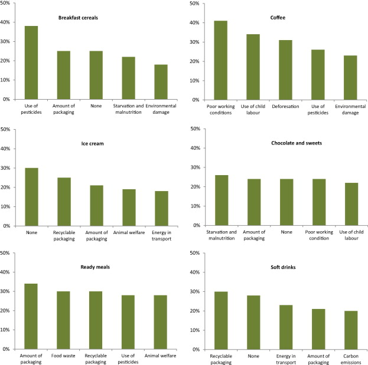

1. [Download: Download full-size image](https://ars.els-cdn.com/content/image/1-s2.0-S0306919213001796-gr3.jpg)

Fig. 3. Major sustainability concern items in connection to food choice.

The results indicate that, while sustainability in food production at the general level is a one-dimensional construct that gives rise to concern in people, this does change when we look at concern for sustainability in the context of specific product categories. At the product category level, some consumers are not concerned about sustainability, and if they are concerned, the issues they are concerned about are related to their beliefs about the production of this specific product category.

### Understanding

Sustainability is an abstract concept and people may attach different meanings to it. Also, the terms used for sustainability in the languages in the six countries studied are quite different, covering newly formed terms (‘Nachhaltigkeit’ in German), adaptations of existing terms (‘sustainability’ in English, ‘sostenibilidad’ in Spanish) and terms that also have another, everyday language meaning (‘hållbarhet’ in Sweden, ‘durabilité’ in French). Even self-reported awareness of the term differed considerably between the countries in the study (from 50% in Poland to 94% in Sweden). When asked to define the term in their own words, respondents in Germany, France, Spain and the UK linked it mostly to protection of the environment, whereas respondents in Poland linked it mostly to the more general issue of maintaining a [standard of living](https://www.sciencedirect.com/topics/social-sciences/living-standard). In Sweden, many respondents came up with the other, everyday language meaning of ‘hållbarhet’, namely the sell-by-date of a product. When asked to pick from a list of 18 items which of them they would associate with the term sustainability, the items picked most often where all related to the environmental dimension of sustainability (e.g., *[environmental impact](https://www.sciencedirect.com/topics/social-sciences/human-activities-effects)* *of use of land and water,* *[environmental impact of food](https://www.sciencedirect.com/topics/food-science/environmental-impact-of-food)* *production*), whereas items related to the ethical dimension of sustainability (e.g., *working conditions in food, child labour in food, world* *[food supply](https://www.sciencedirect.com/topics/social-sciences/food-supply)*) were picked less often.

However, sustainability labels on food products, which usually only cover a particular aspect of sustainability, can be understood even when one’s understanding of the general term sustainability is vague and fuzzy. This can be seen in Table 4, which summarizes the results of respondents’ answers to the multiple choice questions testing for understanding of four particular labels. With one exception, the answer most frequently selected is the correct answer even though we should also note the sizable proportion of respondents answering *I don’t know*, in addition to those choosing a wrong answer. Whether respondents have seen the label before is significantly related to the pattern of answers for all labels (*χ*<sup>2</sup> < .01 in all four cases), but there are clear differences between the labels, suggesting that some labels communicate themselves fairly well even to respondents who have not seen them before. The carbon footprint label and the animal welfare label perform best in this respect, with high proportions of correct answers even for those who did not report having seen the label before, as compared to the Fair Trade label, where only those who have seen it before tend to choose the right answer, and the others answering don’t know or choosing any answer. The main exception is the Rainforest Alliance label, with most respondents believing that this label stands for *protecting wildlife in the rain forest,* which is a wrong answer.

Only 12% of respondents stated to have seen the EU eco-label before, and of these, 20% thought they had seen it on food products (the EU eco-label cannot presently be found on food and drink products).

A formative index for understanding of sustainability labels was formed by counting the number of correct answers, resulting in an index with a range from 0 to 4 (note that, for a formative index like this, usual measures for reliability of composite measures cannot be applied, see Diamantopoulos and Winklhofer, 2001). Determinants of understanding of this index were then investigated by multiple regression similar to the analysis of determinants of motivation in the previous section. Results are in Table 5.

Table 5. Determinants of understanding of sustainability labels (regression).

| Predictor | Model 1 *B* | Model 1 Sig. | Model 2 *B* | Model 2 Sig. | Model 3 *B* | Model 3 Sig. |
| --- | --- | --- | --- | --- | --- | --- |
| Intercept | 1.555 | .000 | .996 | .000 | .835 | .000 |
| *Values* |  |  |  |  |  |  |
| • Achievement |  |  |  |  | −.036 | .036 |
| • Benevolence |  |  |  |  | .063 | .003 |
| • Conformity |  |  |  |  | −.009 | .570 |
| • Hedonism |  |  |  |  | −.014 | .393 |
| • Power |  |  |  |  | .007 | .723 |
| • Security |  |  |  |  | −.040 | .019 |
| • Self-determination |  |  |  |  | .067 | .001 |
| • Stimulation |  |  |  |  | −.057 | .000 |
| • Tradition |  |  |  |  | −.077 | .000 |
| • Universalism |  |  |  |  | .120 | .000 |
| Concern for sustainability in food |  |  | .116 | .000 | .069 | .000 |
| Gender (base: female) | .004 | .908 | .043 | .206 | .090 | .008 |
| *Age (base: 55+)* |  |  |  |  |  |  |
| • 18–24 | .112 | .091 | .191 | .004 | .264 | .000 |
| • 25–34 | .145 | .004 | .205 | .000 | .248 | .000 |
| • 35–44 | .108 | .029 | .150 | .002 | .177 | .000 |
| • 45–54 | .055 | .244 | .077 | .102 | .076 | .108 |
| *Class (base: 5)* |  |  |  |  |  |  |
| • 1 | .042 | .376 | .037 | .436 | .034 | .472 |
| • 2 | .044 | .414 | .038 | .476 | .025 | .633 |
| • 3 | .043 | .556 | .029 | .690 | .005 | .942 |
| • 4 | −.111 | .051 | −.120 | .034 | −.113 | .042 |
| *Country (base: Sweden)* |  |  |  |  |  |  |
| • UK | .628 | .000 | .579 | .000 | .642 | .000 |
| • France | −.068 | .199 | −.125 | .018 | −.055 | .307 |
| • Germany | −.016 | .765 | −.076 | .154 | −.004 | .942 |
| • Spain | −.103 | .070 | −.198 | .001 | −.166 | .004 |
| • Poland | −.305 | .000 | −.316 | .000 | −.257 | .000 |
| Children (base: no) | −.007 | .856 | −.003 | .937 | −.017 | .649 |
| *Education (base: high)* |  |  |  |  |  |  |
| • Low | −.447 | .000 | −.445 | .000 | −.409 | .000 |
| • Medium | −.155 | .000 | −.162 | .000 | −.147 | .000 |
| *R*<sup>2</sup> | .093 | .108 | .136 |  |  |  |

Table 6. Self-reported use of food label information.

| Empty Cell | Mean | Std. deviation |
| --- | --- | --- |
| Price | 6.09 | 1.32 |
| Best before/use by date | 5.94 | 1.46 |
| Quantity/size of product | 5.23 | 1.64 |
| Brand | 4.73 | 1.67 |
| Ingredients list | 4.32 | 1.84 |
| Nutritional benefits (e.g. low fat, reduced salt) | 4.12 | 1.92 |
| Cooking instructions | 4.08 | 1.84 |
| Nutrition information | 4.00 | 1.92 |
| Country of origin | 3.98 | 1.95 |
| Portion information | 3.65 | 1.91 |
| Health benefits (e.g. lowers cholesterol, good for bones) | 3.63 | 1.90 |
| Health logo/symbol (such as “Good for you” or the Sunflower “Eat Well” logo) | 3.23 | 1.85 |
| Organic status | 3.17 | 1.88 |
| Environmental impact (e.g. production, transport) | 2.98 | 1.78 |
| Ethical impact (e.g. working conditions, fair trade) | 2.97 | 1.77 |
| Allergy information | 2.75 | 1.97 |
| *N* = 4408 |  |  |

1 = “Never” and 7 = “Always”.

When buying food and drink products, how often do you look for the following information on the packaging?

The regression analysis shows significant effects for age, country of residence and level of education. Younger respondents tend to have a higher level of understanding. Level of understanding is lowest in Poland and highest in the UK, with the other countries at similar levels in between. The education effect is strongest, with higher levels of understanding for higher levels of education.

### Use

As described above, use was measured in two ways: by measuring self-reported use of a range of types of information available on food packages, and by a choice-based conjoint analysis where respondents had to choose between product descriptions characterized by the presence of ethical and environmental labels, a [nutritional characteristic](https://www.sciencedirect.com/topics/food-science/nutritive-value), and price.

Table 7. Determinants of self-reported use of ethical and environmental information of food.

| Predictor | Model 1 B | Model 1 Sig. | Model 2 B | Model 2 Sig. | Model 3 B | Model 3 Sig. |
| --- | --- | --- | --- | --- | --- | --- |
| Intercept | 6.743 | .000 | .711 | .067 | .730 | .109 |
| *Values* |  |  |  |  |  |  |
| • Achievement |  |  |  |  | .124 | .015 |
| • Benevolence |  |  |  |  | −.144 | .022 |
| • Conformity |  |  |  |  | −.059 | .220 |
| • Hedonism |  |  |  |  | −.083 | .075 |
| • Power |  |  |  |  | .084 | .124 |
| • Security |  |  |  |  | −.215 | .000 |
| • Self-determination |  |  |  |  | −.138 | .017 |
| • Stimulation |  |  |  |  | .195 | .000 |
| • Tradition |  |  |  |  | .128 | .009 |
| • Universalism |  |  |  |  | .248 | .000 |
| Concern for sustainability in food |  |  | 1.247 | .000 | 1.196 | .000 |
| Understanding of sustainability labels (base:high) |  |  | 1.373 | .001 | 1.264 | .001 |
| Concern * Understanding |  |  | −.273 | .001 | −.258 | .001 |
| Gender (base: female) | −.679 | .000 | −.301 | .002 | −.370 | .000 |
| *Age (base: 55+)* |  |  |  |  |  |  |
| • 18–24 | −.778 | .000 | −.018 | .925 | −.251 | .208 |
| • 25–34 | −.652 | .000 | −.082 | .571 | −.256 | .087 |
| • 35–44 | −.565 | .000 | −.167 | .247 | −.239 | .100 |
| • 45–54 | −.507 | .001 | −.312 | .024 | −.328 | .017 |
| *Class (base: 5)* |  |  |  |  |  |  |
| • 1 | .191 | .200 | .146 | .287 | .108 | .431 |
| • 2 | −.079 | .637 | −.125 | .418 | −.115 | .454 |
| • 3 | .011 | .962 | −.127 | .551 | −.193 | .364 |
| • 4 | .055 | .757 | −.031 | .850 | −.051 | .755 |
| *Country (base: Sweden)* |  |  |  |  |  |  |
| • UK | .062 | .728 | −.386 | .021 | −.342 | .045 |
| • France | −.250 | .130 | −.781 | .000 | −.712 | .000 |
| • Germany | .329 | .048 | −.234 | .132 | −.226 | .151 |
| • Spain | .143 | .418 | −.752 | .000 | −.614 | .000 |
| • Poland | .298 | .098 | .174 | .298 | .124 | .478 |
| Children (base: no) | −.044 | .705 | −.009 | .937 | −.004 | .971 |
| *Education (base: high)* |  |  |  |  |  |  |
| • Low | −.320 | .036 | −.320 | .024 | −.223 | .116 |
| • Medium | −.133 | .275 | −.212 | .060 | −.161 | .153 |
| *R*<sup>2</sup> | .023 |  | .166 |  | .181 |  |

Table 8 shows part worth utilities and attribute importances estimated for the conjoint data. In interpreting these results it should be remembered that the stylized product alternatives, which did not include information on major choice criteria like taste and brand, are likely to result in an overestimation of the importance of the ethical and environmental labels. Still, we can see in Table 8 that not only price, but also the nutritional information had much more influence on respondents’ choices than the sustainability labels. The information on fat or sugar content clearly dominates the choices, with low fat or sugar being the clearly preferred alternative. For coffee, the information on caffeine content likewise dominated choices, with a medium content of caffeine the preferred choice. The presence of environmental labels did result in positive utilities, with the Rainforest Alliance label more preferred than the Carbon Foot print label. Also the ethical labels led to positive utilities, with Fair Trade leading to higher utilities than Animal Welfare.

Table 8. Results from conjoint analysis.

| Empty Cell | Chocolate | Coffee | Ice cream | Breakfast cereal | Ready meals | Soft drink |
| --- | --- | --- | --- | --- | --- | --- |
| *Environmental label* |  |  |  |  |  |  |
| • Carbon footprint | .061 | .089 | .051 | .250 | .202 | .234 |
| • Rainforest Alliance | .629 | .557 | .565 | .615 | .509 | .402 |
| • None | −.690 | −.646 | −.617 | −.865 | −.711 | −.636 |
| Importance (%) | 14 | 11 | 11 | 10 | 10 | 9 |
| *Ethical label* |  |  |  |  |  |  |
| • Fair trade | .831 | .826 | .647 | .642 | .634 | .722 |
| • Animal welfare | .101 | .156 | .268 | .323 | .278 | <sup>a</sup> |
| • None | −.933 | −.982 | −.915 | −.966 | −.913 | −.722 |
| Importance (%) | 19 | 16 | 15 | 13 | 13 | 10 |
| *Nutrition* |  |  |  |  |  |  |
| • Low fat/sugar/caffeine | 1.737 | −1.706 | 2.247 | 4.929 | 2.616 | 4.278 |
| • Medium fat/sugar/caffeine | .973 | 1.893 | 1.320 | .202 | 1.466 | .634 |
| • High fat/sugar/caffeine | −2.711 | −.186 | −3.568 | −5.131 | −4.083 | −4.913 |
| Importance (%) | 45 | 52 | 50 | 55 | 49 | 62 |
| *Price* |  |  |  |  |  |  |
| • −10% | 1.721 | 1.822 | 2.580 | 2.346 | 2.741 | 1.898 |
| • Current | .164 | .069 | .059 | .129 | .112 | −.030 |
| • +10% | −1.885 | −1.891 | −2.640 | −2.475 | −2.854 | −1.867 |
| • Importance (%) | 21 | 21 | 25 | 22 | 27 | 19 |
| *N* | 2498 | 2522 | 2375 | 1753 | 1489 | 2212 |

Means of individual part worth utilities and attribute importances.

**a**

Not used for soft drink category.

Table 9. Determinants of inferred use of ethical and environmental information of food.

| Predictor | Model 1 B | Model 1 Sig. | Model 2 B | Model 2 Sig. | Model 3 B | Model 3 Sig. |
| --- | --- | --- | --- | --- | --- | --- |
| *Intercept* |  |  |  |  |  |  |
| • Values | 4.311 | .000 | 3.539 | .000 | 3.520 | .000 |
| • Achievement |  |  |  |  | .014 | .493 |
| • Benevolence |  |  |  |  | −.017 | .488 |
| • Conformity |  |  |  |  | −.037 | .052 |
| • Hedonism |  |  |  |  | −.014 | .464 |
| • Power |  |  |  |  | .017 | .440 |
| • Security |  |  |  |  | −.077 | .000 |
| • Self-determination |  |  |  |  | .005 | .812 |
| • Stimulation |  |  |  |  | −.008 | .684 |
| • Tradition |  |  |  |  | −.018 | .368 |
| • Universalism |  |  |  |  | .148 | .000 |
| Concern for sustainability in food |  |  | .194 | .000 | .160 | .000 |
| Understanding of sustainability labels (base: high) |  |  | −.327 | .000 | −.297 | .000 |
| Gender (base: female) | −.131 | .001 | −.065 | .096 | −.053 | .184 |
| *Age (base: 55+)* |  |  |  |  |  |  |
| • 18–24 | .265 | .001 | .386 | .000 | .376 | .000 |
| • 25–34 | .312 | .000 | .390 | .000 | .376 | .000 |
| • 35–44 | .214 | .000 | .265 | .000 | .260 | .000 |
| • 45–54 | .128 | .023 | .155 | .005 | .146 | .008 |
| *Class (base: 5)* |  |  |  |  |  |  |
| • 1 | .176 | .002 | .162 | .003 | .145 | .005 |
| • 2 | .145 | .022 | .132 | .032 | .130 | .043 |
| • 3 | .178 | .042 | .149 | .080 | .122 | .148 |
| • 4 |  |  |  |  |  |  |
| Country (base: Sweden) | .030 | .657 | .029 | .657 | .028 | .668 |
| • UK | .174 | .010 | −.017 | .803 | .084 | .212 |
| • France | −.945 | .000 | −1.037 | .000 | −.983 | .000 |
| • Germany | −.497 | .000 | −.592 | .000 | −.562 | .000 |
| • Spain | −.778 | .000 | −.928 | .000 | −.877 | .000 |
| • Poland | −1.486 | .000 | −1.459 | .000 | −1.425 | .000 |
| Children (base: no) |  |  |  |  |  |  |
| Education (base: high) | −.024 | .592 | −.016 | .710 | −.026 | .546 |
| • Low | −.268 | .000 | −.199 | .000 | −.162 | .004 |
| • Medium | −.048 | .300 | −.038 | .395 | −.018 | .696 |
| *R*<sup>2</sup> | .177 | .222 | .232 |  |  |  |

Dependent variable is sum of average utility ranges for environmental and ethical labels in conjoint analysis.

Values provide little additional predictive power, reproducing only the effects of universalism and security from Table 7.

## Discussion

In the present study, we have analysed the relationship between [consumer motivation](https://www.sciencedirect.com/topics/social-sciences/consumer-motivation), understanding and use of sustainability labels on food products. The results indicated a low level of use, no matter whether use was measured as self-reported use or as use inferred from the results of a choice-based conjoint analysis where sustainability information was put into the context of price and nutritional information. Use is related to motivation – the more consumers are concerned about sustainability issues with regard to [food production](https://www.sciencedirect.com/topics/social-sciences/food-production), the higher is also the level of use of sustainability labels. However, the effects are not strong and the low level of use is not due to a correspondingly low level of concern about sustainability issues related to food. On the contrary, when asked about the level of concern with issues related to sustainability in food production in general terms, there is generally a moderately high level of concern. However, this level of concern does not translate into corresponding levels of use. Already when consumers are asked to indicate specific issues of concern not with regard to food in general, but with regard to specific product categories, a sizeable share of consumers indicate that they have no concerns. The general concern therefore does not necessarily translate into a product-specific concern that could motivate the use of sustainability labels when choosing food.

Lack of use can also be related to lack of understanding. Sustainability is an abstract and diffuse term and consumers may have difficulty to relate to it. Our results show that most consumers associate it with aspects of environmental protection, and to a lesser extent to ethical issues that are also part of the broader sustainability concept. These difficulties with the general concept seem not, however, to impact on the understanding of specific sustainability labels. Understanding of specific sustainability labels is related to awareness of these labels, and to the ability of these labels to communicate their meaning, i.e., the extent to which they are self-explanatory. Level of understanding is indeed also related to level of use, although the type and size of the relationship depends on how use is measured.

We also investigated to which extent motivation, understanding and use are related to consumers’ pattern of life values, and found patterns largely consistent with the Schwartz theory of values: universalism is the dominant value domain influencing motivation, understanding and use of sustainability labels. Other value domains have smaller influences, and the pattern of results found by and large shows, as expected, that consumers putting higher emphasis on collectivistic as compared to individualistic values also pay more attention to sustainability issues in the context of food.

We found a number of demographic effects as well. Women are more concerned about sustainability and use labels more often than men, but there is no difference in level of understanding. Older people have higher levels of concern, but lower levels of understanding and use. Higher social classes report more use of sustainability labels, but social class has no effect on level of concern or understanding. Having children has, perhaps surprisingly, no influence. Higher education leads to higher levels of understanding and use, but not to higher levels of concern.

We found some interesting country effects as well, and these demonstrate again that the relationship between motivation (measured as level of concern), understanding and use is complex. Although the results may be a bit inflated by response style differences between Sweden, Spain, and the other four countries, results indicate that Poland and Sweden have the lowest level of concern with sustainability issues, whereas Sweden and the UK have the highest level of (inferred) use. Spain and Germany have the highest level of concern, but Spain has a relatively low level of use. Germany and the UK show the most consistent patterns, with high levels of concern, understanding and use compared to the other countries. The country differences found with regard to understanding and use can be affected by differences in rate of adoption of the various labels in the different countries, but as these labels are adopted by multinational companies who then roll them out in various countries, where penetration is additionally dependent on retailer policies, it is difficult to quantify such rates per label, per country.”

From a theoretical perspective, the results are consistent with the motivation-ability-opportunity framework, which implies that the availability of sustainability labels leads to their use only if accompanied by consumer motivation and understanding. However, our results also show that motivation and understanding alone are not sufficient to result in behaviour. Consistent with extant research on the attitude–behaviour relationship, we find that a general concern for sustainability issues does not necessarily translate into behaviour, even when the information is understandable and available. This has partly to do with the trade-off that consumers make when buying food, as the results of the conjoint analysis show. But it has also to do with the fact that weak attitudes affect behaviour only when primed in the behavioural situation, a phenomenon addressed in the context of other forms of environmentally friendly behaviour (e.g., Cornelissen et al., 2008).

The relatively low amounts of explained variance in our regressions suggests that there may be additional factors that have an impact on the use of sustainability labels. There may be other motives than concern for sustainability – for example, some people may think there is prestige in buying fair trade products (Kimura et al., 2012). Use may be inhibited by a lack of credibility of the labels or by uncertainty about which body is responsible for the certification (Borin et al., 2011, Horne, 2009). Finally, use may be simply impeded by a lack of availability of products carrying the label (Vermeir and Verbeke, 2006).

Our results do not imply that sustainability labels do not have a future. They only show that, at present, their use by consumers in Europe is limited. In this context it is also interesting to look at the considerable country differences we found, even after controlling for differences in understanding and motivation. This shows that a high level of concern in some countries is more apt to translate into behaviour than in others. To find reasons for this is an interesting aim for future research. One perspective that could be adopted there is to look into differences in the prominence of sustainability issues on the public agenda, which could relate to salience of the concept in the mind of consumers.

## Acknowledgments

EUFIC receives funding from the food industry and Klaus G. Grunert has received funding from EUFIC to conduct this study.

## References

1. Aertsens et al., 2009

   J. Aertsens, W. Verbeke, K. van Mondelaers, G. Huylenbroeck

   Personal determinants of organic food consumption: a review

   Brit. Food J., 111 (2009), pp. 1140-1167

   View at publisher

   [Crossref](https://doi.org/10.1108/00070700910992961)[View in Scopus](https://www.scopus.com/inward/record.url?eid=2-s2.0-70350379589&partnerID=10&rel=R3.0.0)Google Scholar
2. Baumgartner and Steenkamp, 2001

   H. Baumgartner, J.B. Steenkamp

   Response styles in marketing research: a cross-national investigation

   J. Market. Res., 38 (2001), pp. 143-156

   [View in Scopus](https://www.scopus.com/inward/record.url?eid=2-s2.0-0035534147&partnerID=10&rel=R3.0.0)[Google Scholar](https://scholar.google.com/scholar_lookup?title=Response%20styles%20in%20marketing%20research%3A%20a%20cross-national%20investigation&publication_year=2001&author=H.%20Baumgartner&author=J.B.%20Steenkamp)
3. Borin et al., 2011

   N. Borin, D. Cerf, R. Krishnan

   Consumer effects of environmental impact in product labeling

   J. Consum. Mark., 28 (2011), pp. 76-86

   View at publisher

   [Crossref](https://doi.org/10.1108/07363761111101976)[View in Scopus](https://www.scopus.com/inward/record.url?eid=2-s2.0-78751621237&partnerID=10&rel=R3.0.0)[Google Scholar](https://scholar.google.com/scholar_lookup?title=Consumer%20effects%20of%20environmental%20impact%20in%20product%20labeling&publication_year=2011&author=N.%20Borin&author=D.%20Cerf&author=R.%20Krishnan)
4. Bray et al., 2011

   J. Bray, N. Johns, D. Kilburn

   An exploratory study into the factors impeding ethical consumption

   J. Bus. Ethics, 98 (2011), pp. 597-618

   View at publisher

   [Crossref](https://doi.org/10.1007/s10551-010-0640-9)[View in Scopus](https://www.scopus.com/inward/record.url?eid=2-s2.0-79151468719&partnerID=10&rel=R3.0.0)[Google Scholar](https://scholar.google.com/scholar_lookup?title=An%20exploratory%20study%20into%20the%20factors%20impeding%20ethical%20consumption&publication_year=2011&author=J.%20Bray&author=N.%20Johns&author=D.%20Kilburn)
5. Brecard et al., 2009

   D. Brecard, B. Hlaimi, S. Lucas, Y. Perraudeau, F. Salladare

   Determinants of demand for green products: an application to eco-label demand for fish in Europe

   Ecol. Econ., 69 (2009), pp. 115-125

   [View PDF](https://www.sciencedirect.com/science/article/pii/S0921800909003061/pdfft?md5=da06fea5196d275540f28d59d6e0fdfe&pid=1-s2.0-S0921800909003061-main.pdf)[View article](https://www.sciencedirect.com/science/article/pii/S0921800909003061)[View in Scopus](https://www.scopus.com/inward/record.url?eid=2-s2.0-70349484442&partnerID=10&rel=R3.0.0)Google Scholar
6. Chatzidakis et al., 2007

   A. Chatzidakis, S. Hibbert, A. Smith

   Why people don’t take their concerns about fair trade to the supermarket: the role of neutralisation

   J. Bus. Ethics, 74 (2007), pp. 89-100

   View at publisher

   [Crossref](https://doi.org/10.1007/s10551-006-9222-2)[View in Scopus](https://www.scopus.com/inward/record.url?eid=2-s2.0-34547328085&partnerID=10&rel=R3.0.0)Google Scholar
7. Comas Marti and Seifert, 2012

   Comas Marti, J.M., Seifert, R.W., 2012. Reviewing the Adoption of Ecolabels by Firms, Survey Report. <http://www.imd.org/news/Ecolabels-study.cfm>.

   Google Scholar
8. Cornelissen et al., 2008

   G. Cornelissen, M. Pandelaere, L. Warlop, S. Dewitte

   Positive cueing: promoting sustainable consumer behavior by cueing common environmental behaviors as environmental

   Int. J. Market. Res., 25 (2008), pp. 46-55

   [View PDF](https://www.sciencedirect.com/science/article/pii/S0167811607000699/pdfft?md5=fecf4d5f28b9ed880d2f3e5a5a587b29&pid=1-s2.0-S0167811607000699-main.pdf)[View article](https://www.sciencedirect.com/science/article/pii/S0167811607000699)[View in Scopus](https://www.scopus.com/inward/record.url?eid=2-s2.0-39249083436&partnerID=10&rel=R3.0.0)Google Scholar
9. De Boer et al., 2009

   J. De Boer, J.J. Boersema, H. Aiking

   Consumers’ motivational associations favoring free-range meat or less meat

   Ecol. Econ., 68 (2009), pp. 850-860

   [View PDF](https://www.sciencedirect.com/science/article/pii/S0921800908003029/pdfft?md5=02d4690a7ba8da09712400c7a47fdb5e&pid=1-s2.0-S0921800908003029-main.pdf)[View article](https://www.sciencedirect.com/science/article/pii/S0921800908003029)[View in Scopus](https://www.scopus.com/inward/record.url?eid=2-s2.0-57049167163&partnerID=10&rel=R3.0.0)Google Scholar
10. De Pelsmacker et al., 2005

    P. De Pelsmacker, L. Driesen, G. Rayp

    Do consumers care about ethics? Willingness to pay for fair-trade coffee

    J. Consum. Aff., 39 (2005), pp. 363-385

    View at publisher

    [Crossref](https://doi.org/10.1111/j.1745-6606.2005.00019.x)[View in Scopus](https://www.scopus.com/inward/record.url?eid=2-s2.0-25844495928&partnerID=10&rel=R3.0.0)Google Scholar
11. Diamantopoulos and Winklhofer, 2001

    A. Diamantopoulos, H.M. Winklhofer

    Index construction with formative indicators: an alternative to scale development

    J. Market. Res., 38 (2001), pp. 269-277

    [View in Scopus](https://www.scopus.com/inward/record.url?eid=2-s2.0-0035534144&partnerID=10&rel=R3.0.0)Google Scholar
12. Dutra de Barcellos et al., 2011

    M. Dutra de Barcellos, A. Krystallis, S.M. de Melo Saab, J.O. Kügler, K.G. Grunert

    Investigating the gap between citizens’ sustainability attitudes and food purchasing behaviour: empirical evidence from Brazilian pork consumers

    Int. J. Consum. Stud., 35 (2011), pp. 391-402

    Google Scholar
13. European Commission, 2008

    European Commission, 2008. Sustainable Consumption and Production and Sustainable Industrial Policy Action Plan. COM (2008) 397 Final.

    Google Scholar
14. European Commission, 2012

    European Commission, 2012. Food Information Schemes, Labelling and Logos, Internal Document DG SANCO.

    [Google Scholar](https://scholar.google.com/scholar?q=European%20Commission%2C%202012.%20Food%20Information%20Schemes%2C%20Labelling%20and%20Logos%2C%20Internal%20Document%20DG%20SANCO.)
15. Grankvist and Biel, 2007

    G. Grankvist, A. Biel

    Predictors of purchase of eco-labelled food products: a panel study

    Food Qual. Prefer., 18 (2007), pp. 701-708

    [View PDF](https://www.sciencedirect.com/science/article/pii/S0950329306001546/pdfft?md5=a321029900d4a30a9098ca7a3c978ead&pid=1-s2.0-S0950329306001546-main.pdf)[View article](https://www.sciencedirect.com/science/article/pii/S0950329306001546)[View in Scopus](https://www.scopus.com/inward/record.url?eid=2-s2.0-33846508565&partnerID=10&rel=R3.0.0)[Google Scholar](https://scholar.google.com/scholar_lookup?title=Predictors%20of%20purchase%20of%20eco-labelled%20food%20products%3A%20a%20panel%20study&publication_year=2007&author=G.%20Grankvist&author=A.%20Biel)
16. Grunert, 2011

    K.G. Grunert

    Sustainability in the food sector: a consumer behaviour perspective

    Int. J. Food Sys. Dyn., 2 (2011), pp. 207-218

    [View at publisher](https://doi.org/10.18461/ijfsd.v2i3.232)[Crossref](https://doi.org/10.18461/ijfsd.v2i3.232)[View in Scopus](https://www.scopus.com/inward/record.url?eid=2-s2.0-84875553235&partnerID=10&rel=R3.0.0)[Google Scholar](https://scholar.google.com/scholar_lookup?title=Sustainability%20in%20the%20food%20sector%3A%20a%20consumer%20behaviour%20perspective&publication_year=2011&author=K.G.%20Grunert)
17. Hallahan, 2000

    K. Hallahan

    Enhancing motivation, ability, and opportunity to process public relations messages

    Public. Relat. Rev., 26 (2000), pp. 463-480

    [View PDF](https://www.sciencedirect.com/science/article/pii/S036381110000059X/pdfft?md5=0106d0105019046322bff4b9da828631&pid=1-s2.0-S036381110000059X-main.pdf)[View article](https://www.sciencedirect.com/science/article/pii/S036381110000059X)[View in Scopus](https://www.scopus.com/inward/record.url?eid=2-s2.0-0347252653&partnerID=10&rel=R3.0.0)[Google Scholar](https://scholar.google.com/scholar_lookup?title=Enhancing%20motivation%2C%20ability%2C%20and%20opportunity%20to%20process%20public%20relations%20messages&publication_year=2000&author=K.%20Hallahan)
18. Harzing, 2006

    A.W. Harzing

    Response styles in cross-national survey research

    Int. J. Cross Cult. Manage., 6 (2006), pp. 243-266

    View at publisher

    [Crossref](https://doi.org/10.1177/1470595806066332)[View in Scopus](https://www.scopus.com/inward/record.url?eid=2-s2.0-38049162191&partnerID=10&rel=R3.0.0)[Google Scholar](https://scholar.google.com/scholar_lookup?title=Response%20styles%20in%20cross-national%20survey%20research&publication_year=2006&author=A.W.%20Harzing)
19. Hoogland et al., 2007

    C. Hoogland, J. de Boer, J.J. Boersema

    Food and sustainability: do consumers recognize, understand and value on-package information on production standards?

    Appetite, 49 (2007), pp. 47-57

    [View PDF](https://www.sciencedirect.com/science/article/pii/S0195666307000049/pdfft?md5=2b2a2b5f53c9cc8bd50b81a674ddbee2&pid=1-s2.0-S0195666307000049-main.pdf)[View article](https://www.sciencedirect.com/science/article/pii/S0195666307000049)[View in Scopus](https://www.scopus.com/inward/record.url?eid=2-s2.0-34248544985&partnerID=10&rel=R3.0.0)Google Scholar
20. Horne, 2009

    R.E. Horne

    Limits to labels: the role of eco-labels in the assessment of product sustainability and routes to sustainable consumption

    Int. J. Consum. Stud., 33 (2009), pp. 175-182

    View at publisher

    [Crossref](https://doi.org/10.1111/j.1470-6431.2009.00752.x)[View in Scopus](https://www.scopus.com/inward/record.url?eid=2-s2.0-79954566728&partnerID=10&rel=R3.0.0)Google Scholar
21. Hughner et al., 2007

    R.S. Hughner, P. McDonagh, A. Prothero, C.J. Shultz II, J. Stanton

    Who are organic food consumers? A compilation and review of why people purchase organic food

    J. Consum. Behav., 6 (2007), pp. 94-110

    View at publisher

    [Crossref](https://doi.org/10.1002/cb.210)Google Scholar
22. Janssen and Hamm, 2012

    M. Janssen, U. Hamm

    Product labelling in the market for organic food: consumer preferences and willingness-to-pay for different organic certification logos

    Food Qual. Prefer., 25 (2012), pp. 9-22

    [View PDF](https://www.sciencedirect.com/science/article/pii/S0950329311002631/pdfft?md5=52a8787b3209f5124b002646c837ea2c&pid=1-s2.0-S0950329311002631-main.pdf)[View article](https://www.sciencedirect.com/science/article/pii/S0950329311002631)[View in Scopus](https://www.scopus.com/inward/record.url?eid=2-s2.0-84856070543&partnerID=10&rel=R3.0.0)Google Scholar
23. Johnston, 2008

    Johnston, R.J., 2008. Fish Ecolabels and Consumer Choice: Weighing the Factors. CAB Rev. 3.

    [Google Scholar](https://scholar.google.com/scholar?q=Johnston%2C%20R.J.%2C%202008.%20Fish%20Ecolabels%20and%20Consumer%20Choice%3A%20Weighing%20the%20Factors.%20CAB%20Rev.%203.)
24. Kimura et al., 2012

    A. Kimura, N. Mukawa, M. Yamamoto, T. Masuda, M. Yuasa, S. Goto, T. Oka, Y. Wada

    The influence of reputational concerns on purchase intention of fair-trade foods among young Japanese adults

    Food Qual. Prefer., 26 (2012), pp. 204-210

    [View PDF](https://www.sciencedirect.com/science/article/pii/S095032931200095X/pdfft?md5=8048887546c7cd6ab1c83c85cf78cff6&pid=1-s2.0-S095032931200095X-main.pdf)[View article](https://www.sciencedirect.com/science/article/pii/S095032931200095X)[View in Scopus](https://www.scopus.com/inward/record.url?eid=2-s2.0-84861754062&partnerID=10&rel=R3.0.0)Google Scholar
25. Kimura et al., 2010

    A. Kimura, Y. Wadaa, A. Kamada, T. Masuda, M. Okamoto, S. Goto, D. Tsuzuki, D. Cai, T. Oka, D. Ippeita

    Interactive effects of carbon footprint information and its accessibility on value and subjective qualities of food products

    Appetite, 55 (2010), pp. 271-278

    [View PDF](https://www.sciencedirect.com/science/article/pii/S0195666310004435/pdfft?md5=4eeca0c1c5a04aa680ee5464d7c07341&pid=1-s2.0-S0195666310004435-main.pdf)[View article](https://www.sciencedirect.com/science/article/pii/S0195666310004435)[View in Scopus](https://www.scopus.com/inward/record.url?eid=2-s2.0-77956416335&partnerID=10&rel=R3.0.0)Google Scholar
26. Krystallis et al., 2009

    A.Dutra. Krystallis, M. de Barcellos, J.O. Kügler, W. Verbeke, K.G. Grunert

    Attitudes of European citizens towards pig production systems

    Livestock Sci., 126 (2009), pp. 46-56

    [View PDF](https://www.sciencedirect.com/science/article/pii/S1871141309002066/pdfft?md5=1f9cd00b0d7ebff1fa053833350e9973&pid=1-s2.0-S1871141309002066-main.pdf)[View article](https://www.sciencedirect.com/science/article/pii/S1871141309002066)[View in Scopus](https://www.scopus.com/inward/record.url?eid=2-s2.0-70349227004&partnerID=10&rel=R3.0.0)Google Scholar
27. Levin et al., 2010

    A.M. Levin, I.P. Levin, M.P. Cook

    Measuring and accounting for cross-country response biases in marketing food and drink products

    J. Int. Consum. Market., 22 (2010), pp. 213-222

    View at publisher

    [Crossref](https://doi.org/10.1080/08961530903476295)[View in Scopus](https://www.scopus.com/inward/record.url?eid=2-s2.0-77951438529&partnerID=10&rel=R3.0.0)Google Scholar
28. Lewin, 1951

    K. Lewin

    Field Theory in Social Science

    Harper and Row, New York (1951)

    [Google Scholar](https://scholar.google.com/scholar_lookup?title=Field%20Theory%20in%20Social%20Science&publication_year=1951&author=K.%20Lewin)
29. MacInnis et al., 1991

    D.J. MacInnis, C. Moorman, B.J. Jaworski

    Enhancing and measuring consumers’ motivation, opportunity, and ability to process brand information from ads

    J. Market., 55 (4) (1991), pp. 32-53

    [View at publisher](https://doi.org/10.2307/1251955)[Crossref](https://doi.org/10.2307/1251955)Google Scholar
30. Mainieri et al., 1997

    T. Mainieri, E.G. Barnett, T.R. Valdero, J.B. Unipan, S. Oskamp

    Green buying: the influence of environmental concern on consumer behaviour

    J. Soc. Psychol., 137 (1997), pp. 189-204

    View at publisher

    [Crossref](https://doi.org/10.1080/00224549709595430)[View in Scopus](https://www.scopus.com/inward/record.url?eid=2-s2.0-0031529398&partnerID=10&rel=R3.0.0)Google Scholar
31. McEachern and Warnaby, 2008

    M. McEachern, G. Warnaby

    Exploring the relationship between consumer knowledge and purchase behaviour of value-based labels

    Int. J. Consum. Stud., 32 (2008), pp. 414-426

    View at publisher

    [Crossref](https://doi.org/10.1111/j.1470-6431.2008.00712.x)[View in Scopus](https://www.scopus.com/inward/record.url?eid=2-s2.0-84857656441&partnerID=10&rel=R3.0.0)Google Scholar
32. Napolitano et al., 2008

    F. Napolitano, C. Pacelli, A. Girolami, A. Braghieri

    Effect of information about animal welfare on consumer willingness to pay for yogurt

    J. Dairy Sci., 91 (2008), pp. 910-917

    [View PDF](https://www.sciencedirect.com/science/article/pii/S0022030208713468/pdfft?md5=ce12333eb30cb1673f11558023945465&pid=1-s2.0-S0022030208713468-main.pdf)[View article](https://www.sciencedirect.com/science/article/pii/S0022030208713468)[Crossref](https://doi.org/10.3168/jds.2007-0709)[View in Scopus](https://www.scopus.com/inward/record.url?eid=2-s2.0-40649099126&partnerID=10&rel=R3.0.0)Google Scholar
33. Nash, 2009

    H.A. Nash

    The European Commission's sustainable consumption and production and sustainable industrial policy action plan

    J. Cleaner Prod., 17 (2009), pp. 496-498

    [View PDF](https://www.sciencedirect.com/science/article/pii/S095965260800231X/pdfft?md5=52a4d660a8a1215a342934b40f9cd63f&pid=1-s2.0-S095965260800231X-main.pdf)[View article](https://www.sciencedirect.com/science/article/pii/S095965260800231X)[View in Scopus](https://www.scopus.com/inward/record.url?eid=2-s2.0-58049112907&partnerID=10&rel=R3.0.0)Google Scholar
34. Ölander and Thøgersen, 1995

    F. Ölander, J. Thøgersen

    Understanding of consumer behaviour as a prerequisite for environmental protection

    J. Consum. Policy, 18 (1995), pp. 345-385

    [View in Scopus](https://www.scopus.com/inward/record.url?eid=2-s2.0-0000316235&partnerID=10&rel=R3.0.0)Google Scholar
35. Petty and Cacioppo, 1996

    R.E. Petty, J.T. Cacioppo

    Attitudes and persuasion: Classic and contemporary approaches

    Westview, Boulder, CO (1996)

    [Google Scholar](https://scholar.google.com/scholar_lookup?title=Attitudes%20and%20persuasion%3A%20Classic%20and%20contemporary%20approaches&publication_year=1996&author=R.E.%20Petty&author=J.T.%20Cacioppo)
36. Roberts and Bacon, 1997

    B.A. Roberts, D.R. Bacon

    Exploring the subtle relationships between environmental concern and ecologically conscious behavior

    J. Bus. Res., 40 (1997), pp. 79-89

    [View at publisher](https://doi.org/10.2307/3601880)[Crossref](https://doi.org/10.2307/3601880)[View in Scopus](https://www.scopus.com/inward/record.url?eid=2-s2.0-0031227270&partnerID=10&rel=R3.0.0)Google Scholar
37. Röös and Tjärnemo, 2011

    E. Röös, H. Tjärnemo

    Challenges of carbon labelling of food products: a consumer research perspective

    Brit. Food J., 113 (2011), pp. 982-996

    View at publisher

    [Crossref](https://doi.org/10.1108/00070701111153742)[View in Scopus](https://www.scopus.com/inward/record.url?eid=2-s2.0-79958727939&partnerID=10&rel=R3.0.0)Google Scholar
38. Rothschild, 1999

    M.L. Rothschild

    Carrots, sticks, and promises: a conceptual framework for the management of public health and social issue behaviors

    J. Market., 63 (4) (1999), pp. 24-37

    Google Scholar
39. Schwartz et al., 2001

    S.H. Schwartz, G. Melech, A. Lehmann, S. Burgess, M. Harris, V. Owens

    Extending the cross cultural validity of the theory of basic human values with a different method of measurement

    J. Cross-cult. Psychol., 32 (2001), pp. 519-542

    [View at publisher](https://doi.org/10.1177/0022022101032005001)[Crossref](https://doi.org/10.1177/0022022101032005001)[View in Scopus](https://www.scopus.com/inward/record.url?eid=2-s2.0-0035596066&partnerID=10&rel=R3.0.0)Google Scholar
40. Schwartz, 1992

    S.H. Schwartz

    Universals in the content and structure of values: theoretical advances and empirical tests in 20 countries

    M.P. Zanna (Ed.), Advances in Experimental Social Psychology, Academic Press, San Diego (1992)

    Google Scholar
41. Sirieix et al., 2008

    L. Sirieix, G. Grolleau, B. Schaer

    Do consumers care about food miles? An empirical analysis in France

    Int. J. Consum. Stud., 32 (2008), pp. 508-515

    View at publisher

    [Crossref](https://doi.org/10.1111/j.1470-6431.2008.00711.x)[View in Scopus](https://www.scopus.com/inward/record.url?eid=2-s2.0-77952426161&partnerID=10&rel=R3.0.0)Google Scholar
42. Sirieix, 2008

    Sirieix, L., 2008. What do Purchasers of Fair Trade products want? CAB Rev. 3.

    [Google Scholar](https://scholar.google.com/scholar?q=Sirieix%2C%20L.%2C%202008.%20What%20do%20Purchasers%20of%20Fair%20Trade%20products%20want%3F%20CAB%20Rev.%203.)
43. Thøgersen, 2009

    J. Thøgersen

    Promoting public transport as a subscription service: effects of a free month travel card

    Transp. Policy, 16 (2009), pp. 335-343

    [View PDF](https://www.sciencedirect.com/science/article/pii/S0967070X09001085/pdfft?md5=1ced182dde0bf59ebd65f02ecc5fd0e6&pid=1-s2.0-S0967070X09001085-main.pdf)[View article](https://www.sciencedirect.com/science/article/pii/S0967070X09001085)[View in Scopus](https://www.scopus.com/inward/record.url?eid=2-s2.0-70450245257&partnerID=10&rel=R3.0.0)Google Scholar
44. Thøgersen and Ölander, 2002

    J. Thøgersen, F. Ölander

    Human values and the emergence of a sustainable consumption pattern: a panel study

    J. Econ. Psychol., 23 (2002), pp. 605-630

    [View PDF](https://www.sciencedirect.com/science/article/pii/S0167487002001204/pdfft?md5=4f6f911528716828ff8ae834fd1bb242&pid=1-s2.0-S0167487002001204-main.pdf)[View article](https://www.sciencedirect.com/science/article/pii/S0167487002001204)[View in Scopus](https://www.scopus.com/inward/record.url?eid=2-s2.0-0036792058&partnerID=10&rel=R3.0.0)Google Scholar
45. van Liere and Dunlap, 1981

    K.D. van Liere, R.E. Dunlap

    Environmental concern – does it make a difference how it’s measured

    Environ. Behhav., 13 (1981), pp. 651-676

    [View at publisher](https://doi.org/10.1177/0013916581136001)[Crossref](https://doi.org/10.1177/0013916581136001)[View in Scopus](https://www.scopus.com/inward/record.url?eid=2-s2.0-0019716972&partnerID=10&rel=R3.0.0)[Google Scholar](https://scholar.google.com/scholar_lookup?title=Environmental%20concern%20%20does%20it%20make%20a%20difference%20how%20its%20measured&publication_year=1981&author=K.D.%20van%20Liere&author=R.E.%20Dunlap)
46. Vermeir and Verbeke, 2006

    I. Vermeir, W. Verbeke

    Sustainable food consumption: exploring the consumer “attitude – behavioural intention” gap

    J. Agr. Environ. Ethics, 19 (2006), pp. 169-194

    View at publisher

    [Crossref](https://doi.org/10.1007/s10806-005-5485-3)[View in Scopus](https://www.scopus.com/inward/record.url?eid=2-s2.0-33645547277&partnerID=10&rel=R3.0.0)Google Scholar
47. WCED, 1987

    WCED, 1987. Our Common Future: Report of the World Commission on Environment and Development.

    [Google Scholar](https://scholar.google.com/scholar?q=WCED%2C%201987.%20Our%20Common%20Future%3A%20Report%20of%20the%20World%20Commission%20on%20Environment%20and%20Development.)
48. Zakowska-Biemans, 2011

    S. Zakowska-Biemans

    Polish consumer food choices and beliefs about organic food

    Brit. Food J., 113 (2011), pp. 122-137

    View at publisher

    [Crossref](https://doi.org/10.1108/00070701111097385)[View in Scopus](https://www.scopus.com/inward/record.url?eid=2-s2.0-78651422125&partnerID=10&rel=R3.0.0)[Google Scholar](https://scholar.google.com/scholar_lookup?title=Polish%20consumer%20food%20choices%20and%20beliefs%20about%20organic%20food&publication_year=2011&author=S.%20Zakowska-Biemans)
49. Zander and Hamm, 2010

    K. Zander, U. Hamm

    Consumer preferences for additional ethical attributes of organic food

    Food Qual. Prefer., 21 (2010), pp. 495-503

    [View PDF](https://www.sciencedirect.com/science/article/pii/S0950329310000078/pdfft?md5=7943ff0a16f90f35a440d0da30b89625&pid=1-s2.0-S0950329310000078-main.pdf)[View article](https://www.sciencedirect.com/science/article/pii/S0950329310000078)[View in Scopus](https://www.scopus.com/inward/record.url?eid=2-s2.0-77951974468&partnerID=10&rel=R3.0.0)[Google Scholar](https://scholar.google.com/scholar_lookup?title=Consumer%20preferences%20for%20additional%20ethical%20attributes%20of%20organic%20food&publication_year=2010&author=K.%20Zander&author=U.%20Hamm)

- 2017, Journal of Cleaner Production

### [Linking green skepticism to green purchase behavior](https://www.sciencedirect.com/science/article/pii/S0959652616304103)

- 2016, Journal of Cleaner Production

### [Conceptual models of food choice: influential factors related to foods, individual differences, and society](https://doi.org/10.3390/foods9121898)

- 2020, Foods

### [Trends in the fashion industry. The perception of sustainability and circular economy: A gender/generation quantitative approach](https://doi.org/10.3390/su12072809)

- 2020, Sustainability Switzerland

### [How to SHIFT consumer behaviors to be more sustainable: A literature review and guiding framework](https://doi.org/10.1177/0022242919825649)

- 2019, Journal of Marketing

### [The Global Food-Energy-Water Nexus](https://doi.org/10.1029/2017RG000591)

- 2018, Reviews of Geophysics

[View all citing articles on Scopus](http://www.scopus.com/scopus/inward/citedby.url?partnerID=10&rel=3.0.0&eid=2-s2.0-84891362152&md5=2b8bb938aa96eda5b6a49257d813174)

**<sup>1</sup>**

One of the reviewers noted that, because of country differences, covariances among the variables may differ between the countries and that the estimation of regression coefficients based on the pooled sample, with country differences reflected only in the country dummies, may lead to misleading results. In order to check for this, we repeated the analyses shown in Table 3, Table 5, Table 7, Table 9 separately for each country and compared the pattern of results with those shown in the tables. Of all the coefficients in the countrywise analyses, 77% were comparable to those in Table 3, Table 5, Table 7, Table 9 in terms of direction and significance. Where there were differences, these related mostly to whether effects of the various Schwartz values reached levels of significance or not (in the pooled sample, even small effects are significant due to the large sample size). We therefore find it defensible to proceed with the analysis of the pooled data and take country differences into account by specifying country dummies.

Copyright © 2013 The Authors. Published by Elsevier Ltd.